# Proyecto 3 – Una exploración profunda a la base de nivel de obesidad

## **Proyecto 3 – Una exploración profunda a la base de nivel de obesidad**

> > **Especialización en Machine Learning**

> > **Machine Learning**

> > **Universidad EAN 2024**

> > *Profesor: Sergio David Díaz*

> > **Integrantes de grupo:**
> > - Luis Fernando Cruz.
> > - Daniel Alejandro Rodríguez.
> > - Luisa Fernanda Tirado León.

## Introducción

Este proyecto tiene como objetivo realizar una exploración profunda a la base de datos de niveles de obesidad, que se encuentra disponible en el [Repositorio de Machine Learning de la UCI](https://archive.ics.uci.edu/dataset/544/estimation+of+obesity+levels+based+on+eating+habits+and+physical+condition). Esta base de datos contiene información sobre hábitos alimenticios y condición física de las personas, y se utilizará para estimar los niveles de obesidad.

La base de datos consta de varias variables tanto cualitativas como cuantitativas que describen diferentes aspectos del comportamiento alimenticio y la actividad física de los individuos. El objetivo principal es utilizar técnicas de reducción de dimensionalidad y clustering para identificar patrones y contrastar estos con la variable objetivo, que es el nivel de obesidad.

en una nueva celda de código, vamos a cargar la base de datos y hacer una exploración inicial:

```python
# Importar las bibliotecas necesarias
import pandas as pd

# Cargar la base de datos
url = '/content/ObesityDataSet_raw_and_data_sinthetic.csv'
data = pd.read_csv(url)

# Mostrar las primeras filas del dataset
print(data.head())
```

```
   Gender   Age  Height  Weight family_history_with_overweight FAVC  FCVC  \
0  Female  21.0    1.62    64.0                            yes   no   2.0
1  Female  21.0    1.52    56.0                            yes   no   3.0
2    Male  23.0    1.80    77.0                            yes   no   2.0
3    Male  27.0    1.80    87.0                             no   no   3.0
4    Male  22.0    1.78    89.8                             no   no   2.0

   NCP       CAEC SMOKE  CH2O  SCC  FAF  TUE        CALC  \
0  3.0  Sometimes    no   2.0   no  0.0  1.0          no
1  3.0  Sometimes   yes   3.0  yes  3.0  0.0   Sometimes
2  3.0  Sometimes    no   2.0   no  2.0  1.0  Frequently
3  3.0  Sometimes    no   2.0   no  2.0  0.0  Frequently
4  1.0  Sometimes    no   2.0   no  0.0  0.0   Sometimes

                  MTRANS           NObeyesdad
0  Public_Transportation        Normal_Weight
1  Public_Transportation        Normal_Weight
2  Public_Transportation        Normal_Weight
3                Walking   Overweight_Level_I
4  Public_Transportation  Overweight_Level_II
```

```python
# Mostrar la cantidad de variables y registros
print(f'Cantidad de registros: {data.shape[0]}')
print(f'Cantidad de variables: {data.shape[1]}')

# Determinar cuáles variables son numéricas y cuáles cualitativas
numericas = data.select_dtypes(include=['int64', 'float64']).columns.tolist()
cualitativas = data.select_dtypes(include=['object']).columns.tolist()

# Resumen de la información
print(f'Variables numéricas: {numericas}')
print(f'Variables cualitativas: {cualitativas}')
```

```
Cantidad de registros: 2111
Cantidad de variables: 17
Variables numéricas: ['Age', 'Height', 'Weight', 'FCVC', 'NCP', 'CH2O', 'FAF', 'TUE']
Variables cualitativas: ['Gender', 'family_history_with_overweight', 'FAVC', 'CAEC', 'SMOKE', 'SCC', 'CALC', 'MTRANS', 'NObeyesdad']
```

# Definición de Clústeres según Hábitos y Contraste con la Variable Objetivo

```python
# Importar bibliotecas necesarias
from sklearn.cluster import KMeans
import seaborn as sns
import matplotlib.pyplot as plt

# Seleccionar las características para el clustering (sin la variable objetivo)
features_for_clustering = data.drop(columns=['NObeyesdad'])

# Preprocesar las características usando el mismo preprocesador
preprocessed_features = preprocessor.fit_transform(features_for_clustering)
```

```python
# Aplicar K-means clustering
kmeans = KMeans(n_clusters=3, random_state=42)
clusters = kmeans.fit_predict(preprocessed_features)

# Añadir los clústeres y la variable objetivo al DataFrame original
data['Cluster'] = clusters
data['Cluster'] = data['Cluster'].astype(str)  # Convertir clústeres a tipo cadena para mejor visualización
```

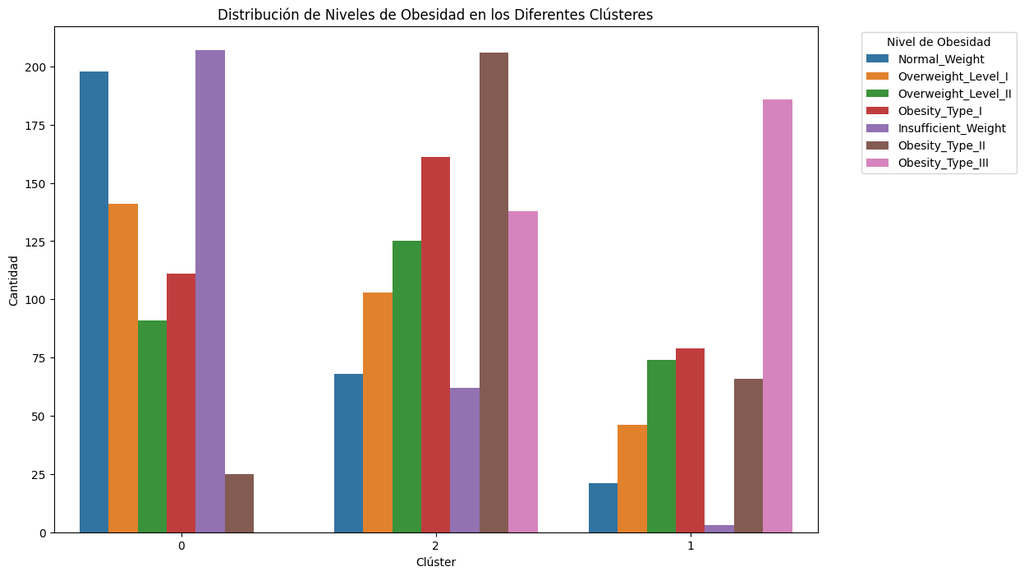

```python
# Visualizar la distribución de la variable objetivo en los diferentes clústeres
plt.figure(figsize=(12, 8))
sns.countplot(x='Cluster', hue='NObeyesdad', data=data)
plt.title('Distribución de Niveles de Obesidad en los Diferentes Clústeres')
plt.xlabel('Clúster')
plt.ylabel('Cantidad')
plt.legend(title='Nivel de Obesidad', bbox_to_anchor=(1.05, 1), loc='upper left')
plt.show()
```

## Paso 5: Partición de la base de datos para entrenamiento y testeo

```python
# Importar las bibliotecas necesarias
from sklearn.model_selection import train_test_split

# Definir la variable objetivo y las variables predictoras
X = data.drop(columns=['NObeyesdad'])  # Variables predictoras
y = data['NObeyesdad']  # Variable objetivo

# Dividir los datos en conjunto de entrenamiento y testeo
X_train, X_test, y_train, y_test = train_test_split(X, y, test_size=0.2, random_state=42)

# Mostrar el tamaño de los conjuntos de entrenamiento y testeo
print(f'Tamaño del conjunto de entrenamiento: {X_train.shape}')
print(f'Tamaño del conjunto de testeo: {X_test.shape}')
```

```
Tamaño del conjunto de entrenamiento: (1688, 16)
Tamaño del conjunto de testeo: (423, 16)
```

## Paso 6: Aplicar modelos de aprendizaje y generar reportes de clasificación

```python
# Importar las bibliotecas necesarias
from sklearn.preprocessing import StandardScaler, OneHotEncoder
from sklearn.compose import ColumnTransformer
from sklearn.pipeline import Pipeline
from sklearn.linear_model import LogisticRegression
from sklearn.ensemble import RandomForestClassifier
from sklearn.metrics import classification_report

# Identificar las columnas categóricas y numéricas
categorical_features = X.select_dtypes(include=['object']).columns
numeric_features = X.select_dtypes(include=['int64', 'float64']).columns

# Crear los transformers para columnas categóricas y numéricas
numeric_transformer = StandardScaler()
categorical_transformer = OneHotEncoder(handle_unknown='ignore')

# Crear el preprocesador
preprocessor = ColumnTransformer(
    transformers=[
        ('num', numeric_transformer, numeric_features),
        ('cat', categorical_transformer, categorical_features)
    ])

# Definir los modelos
modelos = {
    'Regresión Logística': LogisticRegression(max_iter=1000),
    'Random Forest': RandomForestClassifier(n_estimators=100)
}

# Entrenar y evaluar los modelos
for nombre, modelo in modelos.items():
    # Crear un pipeline con el preprocesador y el modelo
    pipeline = Pipeline(steps=[('preprocessor', preprocessor),
                               ('classifier', modelo)])

    # Entrenar el modelo
    pipeline.fit(X_train, y_train)

    # Predecir en el conjunto de testeo
    y_pred = pipeline.predict(X_test)

    # Generar el reporte de clasificación
    print(f'Reporte de clasificación para {nombre}:\n')
    print(classification_report(y_test, y_pred))
    print('-'*80)
```

```
Reporte de clasificación para Regresión Logística:

                     precision    recall  f1-score   support

Insufficient_Weight       0.85      1.00      0.92        56
      Normal_Weight       0.91      0.65      0.75        62
     Obesity_Type_I       0.93      0.90      0.92        78
    Obesity_Type_II       0.90      0.97      0.93        58
   Obesity_Type_III       1.00      1.00      1.00        63
 Overweight_Level_I       0.75      0.75      0.75        56
Overweight_Level_II       0.74      0.84      0.79        50

           accuracy                           0.87       423
          macro avg       0.87      0.87      0.87       423
       weighted avg       0.88      0.87      0.87       423

--------------------------------------------------------------------------------
Reporte de clasificación para Random Forest:

                     precision    recall  f1-score   support

Insufficient_Weight       0.98      0.96      0.97        56
      Normal_Weight       0.81      0.87      0.84        62
     Obesity_Type_I       0.99      0.94      0.96        78
    Obesity_Type_II       0.98      0.98      0.98        58
   Obesity_Type_III       1.00      1.00      1.00        63
 Overweight_Level_I       0.89      0.86      0.87        56
Overweight_Level_II       0.90      0.94      0.92        50

           accuracy                           0.94       423
          macro avg       0.94      0.94      0.94       423
       weighted avg       0.94      0.94      0.94       423

--------------------------------------------------------------------------------
```

## Conclusiones

En este análisis, hemos aplicado dos modelos de aprendizaje supervisado: Regresión Logística y Random Forest, para predecir los niveles de obesidad basados en hábitos alimenticios y condición física.

### Resumen de Resultados

#### Regresión Logística

- **Precision, recall y f1-score**: Los valores de precisión, recall y f1-score varían entre las diferentes clases, con valores muy altos para algunas clases como `Insufficient_Weight` y `Obesity_Type_III`.
- **Exactitud (accuracy)**: La exactitud global del modelo es del 87%, lo que indica que el modelo realiza una buena clasificación general.
- **Promedios macro y ponderado**: Los promedios macro y ponderado son ambos 0.87, lo que sugiere que el modelo tiene un rendimiento consistente en todas las clases.

#### Random Forest

- **Precision, recall y f1-score**: Los valores de precisión, recall y f1-score son consistentemente altos en todas las clases, con la mayoría de las clases alcanzando valores superiores al 0.90.
- **Exactitud (accuracy)**: La exactitud global del modelo es del 94%, lo que indica un rendimiento excelente en la clasificación.
- **Promedios macro y ponderado**: Los promedios macro y ponderado son ambos 0.94, indicando un rendimiento equilibrado y fuerte en todas las clases.

### Próximos pasos

- **Ajuste de hiperparámetros**: Realizar una búsqueda de hiperparámetros para ambos modelos utilizando técnicas como Grid Search o Random Search para optimizar su rendimiento.
- **Validación cruzada**: Implementar validación cruzada para asegurarnos de que los modelos generalicen bien a otros conjuntos de datos.
- **Análisis adicional**: Investigar más sobre las variables más importantes en Random Forest y cómo afectan la clasificación para obtener más información sobre el comportamiento del modelo.

### Referencias

- Zainea Maya, C. I. (2022). Seminario de Programación (Version 1.0.0) [Computer software]. https://doi.org/10.5281/zenodo.1234
- Bagnato, J. (2017). Aprende Machine Learning en Español: Teoría + Práctica. https://leanpub.com/aprendeml

## Ajuste de Hiperparámetros

```python
# Importar las bibliotecas necesarias
from sklearn.model_selection import GridSearchCV

# Definir los parámetros para la búsqueda en Regresión Logística
param_grid_lr = {
    'classifier__C': [0.1, 1.0, 10, 100],
    'classifier__solver': ['liblinear', 'lbfgs']
}

# Crear el pipeline para Regresión Logística
pipeline_lr = Pipeline(steps=[('preprocessor', preprocessor),
                              ('classifier', LogisticRegression(max_iter=1000))])

# Realizar la búsqueda de hiperparámetros para Regresión Logística
grid_search_lr = GridSearchCV(pipeline_lr, param_grid_lr, cv=5, scoring='accuracy')
grid_search_lr.fit(X_train, y_train)

# Mostrar los mejores parámetros y la mejor exactitud
print("Mejores parámetros para Regresión Logística:", grid_search_lr.best_params_)
print("Mejor exactitud para Regresión Logística:", grid_search_lr.best_score_)

# Definir los parámetros para la búsqueda en Random Forest
param_grid_rf = {
    'classifier__n_estimators': [50, 100, 200],
    'classifier__max_depth': [None, 10, 20, 30]
}

# Crear el pipeline para Random Forest
pipeline_rf = Pipeline(steps=[('preprocessor', preprocessor),
                              ('classifier', RandomForestClassifier(random_state=42))])

# Realizar la búsqueda de hiperparámetros para Random Forest
grid_search_rf = GridSearchCV(pipeline_rf, param_grid_rf, cv=5, scoring='accuracy')
grid_search_rf.fit(X_train, y_train)

# Mostrar los mejores parámetros y la mejor exactitud
print("Mejores parámetros para Random Forest:", grid_search_rf.best_params_)
print("Mejor exactitud para Random Forest:", grid_search_rf.best_score_)
```

[output not shown]

```
Mejores parámetros para Regresión Logística: {'classifier__C': 100, 'classifier__solver': 'lbfgs'}
Mejor exactitud para Regresión Logística: 0.9555774059312064
Mejores parámetros para Random Forest: {'classifier__max_depth': None, 'classifier__n_estimators': 200}
Mejor exactitud para Random Forest: 0.9401664530402261
```

# Análisis del Ajuste de Hiperparámetros

## Resultados del Ajuste de Hiperparámetros

### Regresión Logística

- **Mejores Parámetros**:
  - `C`: 100
  - `solver`: 'lbfgs'
- **Mejor Exactitud**: 95.56%

### Random Forest

- **Mejores Parámetros**:
  - `max_depth`: None
  - `n_estimators`: 200
- **Mejor Exactitud**: 94.02%

## Implementación de Validación Cruzada

```python
from sklearn.model_selection import cross_val_score

# Validación cruzada para Regresión Logística con los mejores parámetros
best_pipeline_lr = grid_search_lr.best_estimator_
scores_lr = cross_val_score(best_pipeline_lr, X_train, y_train, cv=5, scoring='accuracy')
print("Exactitud media para Regresión Logística:", scores_lr.mean())

# Validación cruzada para Random Forest con los mejores parámetros
best_pipeline_rf = grid_search_rf.best_estimator_
scores_rf = cross_val_score(best_pipeline_rf, X_train, y_train, cv=5, scoring='accuracy')
print("Exactitud media para Random Forest:", scores_rf.mean())
```

```
Exactitud media para Regresión Logística: 0.9555774059312064
Exactitud media para Random Forest: 0.9401664530402261
```